# Final Assessment — Introduction to Data Science

11372 & 11516

17 November 2026

```r
knitr::opts_chunk$set(echo = TRUE, warning = FALSE, message = FALSE)

## --------------------------------------------------------------------------
##  DO NOT EDIT personalise.R. Run this chunk once to build your dataset.
## --------------------------------------------------------------------------
source("personalise.R")

my <- make_my_dataset(params$studentID,
                      raw_dir = "data_raw",
                      out_dir = "data")
```

```
## Student ID   : u3318186
## Seed         : 43084710
## Window       : 2003 - 2022
## Countries    : 151
## Files written to C:\Users\lochi\OneDrive\Desktop\UC\Intro to Data Science\Assignment 2\data
##   Emissions.csv   3025 rows
##   Renewables.csv  147 rows x 21 cols
##   Consumption.csv 1957 rows
##   Countries.csv   151 rows
## FINGERPRINT  : EM-612876-8802-7625
```

```r
# Load the packages you need here.
packages <- c("tidyverse", "ggplot2", "usethis", "lubridate", "dplyr", "GGally", "glmnet")
lapply(packages, library, character.only = TRUE)
```

[output not shown]

# Introduction

*Briefly introduce the dataset, the questions you set out to answer, and how this report is organised. Half a page is plenty.*

This report examines CO2 emissions and renewable electricity generation across 151 countries between 2003 and 2022, using a personalised dataset generated from my student ID. It investigates how emissions changed over time, how country rankings differ when accounting for population, and how international trade affects the distinction between production based and consumption based emissions.

The analysis begins with data cleaning, joining and feature creation, followed by exploratory visualisations and comparisons. Linear and Lasso regression models are then evaluated to investigate relationships between cumulative emissions and economic and population variables. Finally, a dashboard presents the main findings for a public audience, with attention to data limitations and fair comparisons between countries.

## Assumptions

*State any assumptions you are making about the data or the analysis before you begin.*

Regional countries have comparable renewable generation rates.

# Task 1: Data preparation and wrangling

### 1.1 Import the four CSV files

```r
emissionsRaw <- read_csv("data/Emissions.csv", trim_ws = TRUE)
renewablesRaw <- read_csv("data/Renewables.csv", trim_ws = TRUE)
consumptionRaw <- read_csv("data/Consumption.csv", trim_ws = TRUE)
countriesRaw <- read_csv("data/Countries.csv", trim_ws = TRUE)

glimpse(emissionsRaw)
```

```
## Rows: 3,025
## Columns: 6
## $ iso_code          <chr> "ABW", "ABW", "ABW", "ABW", "ABW", "ABW", "ABW", "AB…
## $ location          <chr> "Aruba", "Aruba", "Aruba", "Aruba", "Aruba", "Aruba"…
## $ region            <chr> "North America", "North America", "North America", "…
## $ year              <dbl> 2003, 2004, 2005, 2006, 2007, 2008, 2009, 2010, 2011…
## $ annual_co2_mt     <dbl> 2.561, 2.616, 2.715, 2.711, 2.821, 2.656, 2.627, 2.5…
## $ annual_oil_co2_mt <dbl> 2.561, 2.616, 2.715, 2.711, 2.821, 2.656, 2.627, 2.5…
```

```r
glimpse(renewablesRaw)
```

```
## Rows: 147
## Columns: 21
## $ Country.Region <chr> "Afghanistan", "Albania", "Angola", "Antigua and Barbud…
## $ `2003`         <dbl> 0.63, 5.12, 1.24, 0.00, 34.76, 1.96, 0.00, 18.66, 35.24…
## $ `2004`         <dbl> 0.56, 5.41, 1.75, 0.00, 31.40, 1.98, 0.00, 19.38, 39.62…
## $ `2005`         <dbl> 0.59, 5.32, 2.22, 0.00, 35.21, 1.75, 0.00, 20.72, 40.88…
## $ `2006`         <dbl> 0.64, 4.95, 2.54, 0.00, 39.14, 1.81, 0.00, 21.14, 40.66…
## $ `2007`         <dbl> 0.75, 2.76, 2.49, 0.00, 32.35, 1.83, 0.00, 20.29, 43.17…
## $ `2008`         <dbl> 0.54, 3.76, 3.15, 0.00, 32.45, 1.78, 0.00, 19.12, 44.53…
## $ `2009`         <dbl> 0.78, 5.20, 3.27, 0.00, 35.85, 2.00, 0.03, 20.16, 47.18…
## $ `2010`         <dbl> 0.75, 7.57, 3.71, 0.00, 34.77, 2.54, 0.11, 22.16, 44.99…
## $ `2011`         <dbl> 0.60, 4.13, 4.02, 0.00, 32.61, 2.46, 0.11, 30.61, 40.91…
## $ `2012`         <dbl> 0.74, 4.72, 5.48, 0.00, 30.99, 2.30, 0.14, 30.27, 51.33…
## $ `2013`         <dbl> 0.89, 6.96, 4.73, 0.00, 34.77, 2.15, 0.15, 35.53, 50.50…
## $ `2014`         <dbl> 1.00, 4.72, 5.05, 0.00, 34.54, 1.97, 0.16, 32.76, 50.20…
## $ `2015`         <dbl> 1.03, 5.89, 5.34, 0.01, 34.43, 2.18, 0.18, 35.80, 47.59…
## $ `2016`         <dbl> 1.06, 7.78, 6.43, 0.00, 31.49, 2.33, 0.14, 41.74, 51.08…
## $ `2017`         <dbl> 1.09, 4.53, 7.72, 0.01, 33.68, 2.25, 0.14, 39.19, 51.05…
## $ `2018`         <dbl> 0.97, 8.55, 10.44, 0.01, 35.22, 2.31, 0.16, 49.49, 50.0…
## $ `2019`         <dbl> 1.28, 5.20, 11.58, 0.01, 34.78, 2.41, 0.17, 55.26, 54.6…
## $ `2020`         <dbl> 1.06, 5.31, 12.71, 0.02, 36.62, 1.92, 0.17, 64.28, 55.4…
## $ `2021`         <dbl> 0.93, 8.94, 12.71, 0.02, 37.04, 2.49, 0.17, 77.27, 52.7…
## $ `2022`         <dbl> 0.83, 6.97, 13.08, 0.02, 42.27, 3.37, 0.17, 87.44, 50.4…
```

```r
glimpse(consumptionRaw)
```

```
## Rows: 1,957
## Columns: 3
## $ `Country Code`    <chr> "ALB", "ALB", "ALB", "ALB", "ALB", "ALB", "ALB", "AL…
## $ Year              <chr> "2003", "2004", "2005", "2006", "2007", "2008", "200…
## $ `Consumption CO2` <dbl> 5.944, 5.529, 5.853, 5.834, 6.058, 6.627, 6.742, 6.5…
```

```r
glimpse(countriesRaw)
```

```
## Rows: 151
## Columns: 5
## $ countryCode  <chr> "ABW", "AFG", "AGO", "ALB", "AND", "ARE", "ARG", "ARM", "…
## $ Country      <chr> "Aruba", "Afghanistan", "Angola", "Albania", "Andorra", "…
## $ popData2022  <dbl> 107792, 40578847, 35635028, 2827614, 79722, 10242085, 454…
## $ GDP          <dbl> NA, 53303, 158346, 36171, NA, 779702, 854914, 39722, NA, …
## $ `GDP/capita` <dbl> NA, 1314, 4444, 12792, NA, 76127, 18827, 13788, NA, 51305…
```

```r
# summary(emissionsRaw)
# summary(renewablesRaw)
# summary(consumptionRaw)
# summary(countriesRaw)

# select(renewablesRaw, Country.Region)
```

### 1.2 Reshape `Renewables.csv` to one row per country per year

*Remember: this file contains rows that are not countries.*

```r
renewablesData <- renewablesRaw %>%
  # Remove world and european union rows
  filter(!Country.Region %in% c("World", "European Union (27)")) %>%
  rename(Country = Country.Region) %>%
  # Reshape renewables
  pivot_longer(cols = -Country,
               names_to = "Year",
               values_to = "Renewables"
  )

head(renewablesData)
```

```
## # A tibble: 6 × 3
##   Country     Year  Renewables
##   <chr>       <chr>      <dbl>
## 1 Afghanistan 2003        0.63
## 2 Afghanistan 2004        0.56
## 3 Afghanistan 2005        0.59
## 4 Afghanistan 2006        0.64
## 5 Afghanistan 2007        0.75
## 6 Afghanistan 2008        0.54
```

*What did you do with the non-country rows, and why?*

The ‘World’ and ‘European Union (27)’ totals overlap with the individual country observations. These aggregate rows were removed to prevent double counting and ensure the dataset only contains countries.

### 1.3 Rename the columns

```r
emissionsData <- emissionsRaw %>%
  rename(
    ISO = iso_code,
    Country = location,
    Region = region,
    Year = year,
    CO2 = annual_co2_mt,
    OilCO2 = annual_oil_co2_mt
  )

consumptionData <- consumptionRaw %>%
  rename(
    ISO = `Country Code`,
    ConsCO2 = `Consumption CO2`
  )

countriesData <- countriesRaw %>%
  rename(
    ISO = countryCode,
    Country = Country,
    Population = popData2022,
    GDPCapita = `GDP/capita`
  )
```

### 1.4 Make `Year` consistent across all data frames

```r
emissionsData <- emissionsData %>%
  mutate(Year = as.integer(Year))

renewablesData <- renewablesData %>%
  mutate(Year = as.integer(Year))

consumptionData <- consumptionData %>%
  mutate(
    # Capitalise all codes
    ISO = str_to_upper(ISO),
    # Extracts the year digits from years containing additional characters
    Year = as.integer(str_extract(Year, "\\d{4}"))
  )
```

The consumption data frame is the only data frame containing inconsistent year values.

### 1.5 Merge the five new variables into the master data frame

*Add `Renewables`, `ConsCO2`, `Population`, `GDP`, `GDPCapita`.*

```r
# Remove duplicate rows
emissionsData <- distinct(emissionsData)

# Fix differing country names in renewablesData
renewablesData <- renewablesData %>%
  mutate(
    Country = recode(
      Country,
      "Côte d'Ivoire" = "Cote d'Ivoire",
      "Congo, Dem. Rep." = "Democratic Republic of Congo",
      "Republic of Korea" = "South Korea",
      "United Republic of Tanzania" = "Tanzania"
    )
  )

# Correct Cameroons population scale
countriesData <- countriesData %>%
  mutate(
    Population = if_else(ISO == "CMR",
      Population * 1000,
      Population
    )
  )

# Count how many rows fail to match for each dataset
unmatchedRenewables <- emissionsData %>%
  anti_join(
    renewablesData,
    by = c("Country", "Year")
  )

unmatchedConsumption <- emissionsData %>%
  anti_join(
    consumptionData,
    by = c("ISO", "Year")
  )

unmatchedCountries <- emissionsData %>%
  anti_join(
    countriesData,
    by = "ISO"
  )

# Return the fail count as a table
unmatchedRows <- tibble(
  source = c("Renewables", "Consumption", "Countries"),
  unmatchedRows = c(
    nrow(unmatchedRenewables),
    nrow(unmatchedConsumption),
    nrow(unmatchedCountries)
  )
)

unmatchedRows
```

```
## # A tibble: 3 × 2
##   source      unmatchedRows
##   <chr>               <int>
## 1 Renewables            120
## 2 Consumption          1063
## 3 Countries               0
```

```r
# Create master table while preserving all emissions data entries
masterData <- emissionsData %>%
  left_join(
    renewablesData,
    by = c("Country", "Year")
  ) %>%
  left_join(
    consumptionData,
    by = c("ISO", "Year")
  ) %>%
  left_join(
    countriesData %>% select(ISO, Population, GDP, GDPCapita), by = "ISO"
  )

# Check missing values for each column
colSums(is.na(masterData))
```

```
##        ISO    Country     Region       Year        CO2     OilCO2 Renewables
##          0          0          0          0          0          0        125
##    ConsCO2 Population        GDP  GDPCapita
##       1063          0        460        460
```

```r
dim(masterData)
```

```
## [1] 3020   11
```

*How many rows failed to match on each join, and what did you do about them?*

After standardising join keys and removing duplicates, 120 rows failed to match the renewables data, 1,063 failed to match the consumption data, and none failed to match the country reference data. Left joins ensured all 3,020 emissions observations were preserved, with unmatched supplementary values initially joined as NA. These missing values were fixed in 1.6.

### 1.6 Handle the NAs

```r
# Function for estimating missing values using known values
interpolateSeries <- function(yearValues, seriesValues) {
  knownValues <- !is.na(seriesValues)

  # If there are insufficient values, return the values unchanged
  if (sum(knownValues) < 2) {
    return(seriesValues)
  }

  approx(
    x = yearValues[knownValues],
    y = seriesValues[knownValues],
    xout = yearValues,
    rule = 2
  )$y
}

# Mark invalid values as missing
masterData <- masterData %>%
  mutate(
    CO2 = if_else(CO2 < 0, NA_real_, CO2),
    OilCO2 = na_if(OilCO2, -999)
  )

# Apply function to missing values
masterData <- masterData %>%
  arrange(ISO, Year) %>%
  group_by(ISO) %>%
  mutate(
    CO2 = interpolateSeries(Year, CO2),
    OilCO2 = round(interpolateSeries(Year, OilCO2), 3),
    Renewables = interpolateSeries(Year, Renewables),
    ConsCO2 = interpolateSeries(Year, ConsCO2)
  ) %>%
  ungroup()

# Fill remaining renewables using regional rates from the countries region
masterData <- masterData %>%
  group_by(Region, Year) %>%
  mutate(
    Renewables = coalesce(
      Renewables,
      round(
        median(Renewables * 1000000 / Population, TRUE) * Population / 1000000, 2)
    )
  ) %>%
  ungroup()

# Calculate regional income medians from country table
incomeBenchmarks <- countriesData %>%
  left_join(
    distinct(emissionsData, ISO, Region),
    by = "ISO"
  ) %>%
  group_by(Region) %>%
  summarise(regionalIncome = median(GDPCapita, TRUE))

# Fill remaining consumption and economic values
masterData <- masterData %>%
  left_join(incomeBenchmarks, by = "Region") %>%
  mutate(
    ConsCO2 = coalesce(ConsCO2, CO2),
    GDPCapita = coalesce(GDPCapita, regionalIncome),
    GDP = coalesce(
      GDP,
      round(GDPCapita * Population / 1000000)
    )
  ) %>%
  select(-regionalIncome)

# Check missing values for each column
colSums(is.na(masterData))
```

```
##        ISO    Country     Region       Year        CO2     OilCO2 Renewables
##          0          0          0          0          0          0          0
##    ConsCO2 Population        GDP  GDPCapita
##          0          0          0          0
```

*Justify your treatment of each variable. Different variables may warrant different choices.*

Different treatments were applied according to each variable’s meaning and the available data.

CO2: Negative observations were treated as invalid and replaced with NA. Missing values were then estimated using linear interpolation within each country, using neighbouring years to preserve the country’s emissions trend.

OilCO2: The invalid placeholder value of -999 was replaced with NA, followed by interpolation within each country. For missing endpoints, the nearest available observation was used because interpolation between two surrounding years was not possible.

Renewables: Missing observations were first interpolated within each country. Remaining gaps were filled using the median renewable generation per million people for the same region and year, scaled to the country’s population to account for differences in country size.

ConsCO2: Missing observations were first interpolated within each country. Remaining NAs were replaced with production-based CO2 emissions. This provides a datapoint when consumption data is unavailable, but assumes zero net imported emissions.

GDPCapita: Missing values were replaced with the regional median from the country table. The median limits the influence of unusually wealthy countries, although it may not accurately represent an individual country’s income.

GDP: Missing values were calculated from GDP per capita multiplied by population and divided by one million to match GDP’s units. This maintains consistency between the economic variables.

### 1.7 Add `Decade` and `Period`

```r
masterData <- masterData %>%
  mutate(
    Decade = paste(
      (Year %/% 10) * 10,
      "s", sep = ""
    ),
    Period = if_else(
      Year < 2016,
      "Pre-Paris",
      "Post-Paris"
    )
  )
```

### 1.8 Add the four cumulative variables

*`CumCO2`, `CumOilCO2`, `CumRenew`, `CumConsCO2`.*

```r
masterData <- masterData %>%
  arrange(ISO, Year) %>%
  group_by(ISO) %>%
  mutate(
    CumCO2 = cumsum(CO2),
    CumOilCO2 = cumsum(OilCO2),
    CumRenew = cumsum(Renewables),
    CumConsCO2 = cumsum(ConsCO2)
  ) %>%
  ungroup()
```

### 1.9 Add `NetImported` and `OilShare`

```r
masterData <- masterData %>%
  mutate(
    # NetImported is zero for countries whose consumption was estimated from production
    NetImported = CumConsCO2 - CumCO2,
    OilShare = round(CumOilCO2 / CumCO2, 3)
  )
```

### 1.10 Add the four per-capita variables

*`CO2_PC`, `OilCO2_PC`, `Renew_PC`, `ConsCO2_PC`.*

```r
masterData <- masterData %>%
  mutate(
    CO2_PC = round(CumCO2 * 1000000 / Population, 3),
    OilCO2_PC = round(CumOilCO2 * 1000000 / Population, 3),
    Renew_PC = round(CumRenew * 1000000 / Population, 3),
    ConsCO2_PC = round(CumConsCO2 * 1000000 / Population, 3)
  )
```

```r
# A quick look at your finished master data frame.
dim(masterData)
```

```
## [1] 3020   23
```

```r
str(masterData)
```

```
## tibble [3,020 × 23] (S3: tbl_df/tbl/data.frame)
##  $ ISO        : chr [1:3020] "ABW" "ABW" "ABW" "ABW" ...
##  $ Country    : chr [1:3020] "Aruba" "Aruba" "Aruba" "Aruba" ...
##  $ Region     : chr [1:3020] "North America" "North America" "North America" "North America" ...
##  $ Year       : int [1:3020] 2003 2004 2005 2006 2007 2008 2009 2010 2011 2012 ...
##  $ CO2        : num [1:3020] 2.56 2.62 2.71 2.71 2.82 ...
##  $ OilCO2     : num [1:3020] 2.56 2.62 2.71 2.71 2.82 ...
##  $ Renewables : num [1:3020] 0 0 0 0 0 0 0.03 0.11 0.11 0.14 ...
##  $ ConsCO2    : num [1:3020] 2.56 2.62 2.71 2.71 2.82 ...
##  $ Population : num [1:3020] 107792 107792 107792 107792 107792 ...
##  $ GDP        : num [1:3020] 1301 1301 1301 1301 1301 ...
##  $ GDPCapita  : num [1:3020] 12071 12071 12071 12071 12071 ...
##  $ Decade     : chr [1:3020] "2000s" "2000s" "2000s" "2000s" ...
##  $ Period     : chr [1:3020] "Pre-Paris" "Pre-Paris" "Pre-Paris" "Pre-Paris" ...
##  $ CumCO2     : num [1:3020] 2.56 5.18 7.89 10.6 13.42 ...
##  $ CumOilCO2  : num [1:3020] 2.56 5.18 7.89 10.6 13.42 ...
##  $ CumRenew   : num [1:3020] 0 0 0 0 0 0 0.03 0.14 0.25 0.39 ...
##  $ CumConsCO2 : num [1:3020] 2.56 5.18 7.89 10.6 13.42 ...
##  $ NetImported: num [1:3020] 0 0 0 0 0 0 0 0 0 0 ...
##  $ OilShare   : num [1:3020] 1 1 1 1 1 1 1 1 1 1 ...
##  $ CO2_PC     : num [1:3020] 23.8 48 73.2 98.4 124.5 ...
##  $ OilCO2_PC  : num [1:3020] 23.8 48 73.2 98.4 124.5 ...
##  $ Renew_PC   : num [1:3020] 0 0 0 0 0 ...
##  $ ConsCO2_PC : num [1:3020] 23.8 48 73.2 98.4 124.5 ...
```

## 1A. Data Quality Audit Report

*Approximately 250 words in total across the three parts below. Every claim must reference a specific value, country, year or column from **your** data.*

### i. Defect inventory

*Complete the table. Add rows as needed — there are more defects than there are rows here.*

| File | Column | Rows affected (Example row) | How I detected it | How I handled it |
| --- | --- | --- | --- | --- |
| Emissions.csv | All | 5 rows (Peru, 2009) | duplicated() | Removed using distinct() |
| Emissions.csv | CO2 | 3 (Cameroon, 2012) | Filtered negative values | Interpolated within country |
| Emissions.csv | OilCO2 | 6 (Moldova, 2003) | Filtered -999 | Interpolated using nearest observation at endpoints |
| Renewables.csv | Country.Region | 2 aggregate rows (World/EU) | Inspected names | Excluded aggregate rows |
| Renewables.csv | Country.Region | 6 names (South Korea, 2003-2022) | Inspected names | Trimmed whitespace and recoded variants |
| Renewables.csv | Country.Region | 5 cells (Comoros, 2011-2015) | Checked missing values | Interpolated |
| Renewables.csv | Country.Region | 120 country-years (Ukraine, 2003-2022) | anti_join() | Population-scaled regional medians |
| Consumption.csv | Country Code | 78 (Albania, 2018) | Compared original/standardised codes | Trimmed whitespace and capitalised |
| Consumption.csv | Year | 117 (UAE, 2007) | Regular expression check | Extracted integer from character |
| Consumption.csv | Missing observations | 1063 (Panama, 2006) | anti_join() | Interpolated, production estimate for absent series |
| Countries.csv | Population | 1 (Cameroon, 2022) | Compared with GDP calculated population | Multiplied by 1000 |
| Countries.csv | GDP/GDPCapita | 23 countries (Aruba, 2022) | Counted NAs | Derived from median regional income |

```r
# The code you used to find the defects.

# Use raw datasets without trimming
consumptionAudit <- read_csv("data/Consumption.csv", col_types = cols(.default = col_character()), trim_ws = FALSE)

renewablesAudit <- read_csv("data/Renewables.csv", trim_ws = FALSE, show_col_types = FALSE)

# Exact duplicates and invalid oil observations
duplicateRows <- emissionsRaw[
  duplicated(emissionsRaw),
]

duplicateRows
```

```
## # A tibble: 5 × 6
##   iso_code location           region        year annual_co2_mt annual_oil_co2_mt
##   <chr>    <chr>              <chr>        <dbl>         <dbl>             <dbl>
## 1 DOM      Dominican Republic North Ameri…  2014         21.3              14.7
## 2 FJI      Fiji               Oceania       2020          1.37              1.37
## 3 IDN      Indonesia          Asia          2013        493.              234.
## 4 NZL      New Zealand        Oceania       2021         34.6              19.7
## 5 PER      Peru               South Ameri…  2009         39.4              23.7
```

```r
emissionsRaw %>%
  filter(annual_oil_co2_mt == -999)
```

```
## # A tibble: 6 × 6
##   iso_code location    region  year annual_co2_mt annual_oil_co2_mt
##   <chr>    <chr>       <chr>  <dbl>         <dbl>             <dbl>
## 1 AFG      Afghanistan Asia    2017          9.31              -999
## 2 HKG      Hong Kong   Asia    2019         41.9               -999
## 3 KEN      Kenya       Africa  2011         12.2               -999
## 4 LVA      Latvia      Europe  2010          8.56              -999
## 5 MDA      Moldova     Europe  2003          4.40              -999
## 6 UKR      Ukraine     Europe  2007        337.                -999
```

```r
# Counts of consumption format problems
consumptionAudit %>%
  summarise(
    inconsistentCodes = sum(
      `Country Code` != str_to_upper(str_trim(`Country Code`))
    ),
    inconsistentYears = sum(!str_detect(Year, "^\\d{4}$"))
  )
```

```
## # A tibble: 1 × 2
##   inconsistentCodes inconsistentYears
##               <int>             <int>
## 1                78               117
```

```r
# Format problem examples
consumptionAudit %>%
  filter(
    !str_detect(Year, "^\\d{4}$") |
      str_detect(`Consumption CO2`, fixed(","))
  ) %>%
  head(10)
```

```
## # A tibble: 10 × 3
##    `Country Code` Year       `Consumption CO2`
##    <chr>          <chr>      <chr>
##  1 ARE            2007.0     189.206
##  2 ARE            FY2010     216.543
##  3 ARG            FY2020     160.073
##  4 ARG            FY2022     183.846
##  5 ARM            2015.0     6.073
##  6 AUS            01/01/2003 342.504
##  7 BEN            2010.0     7.584
##  8 BFA            01/01/2009 2.242
##  9 BGR            01/01/2021 40.932
## 10 BHR            2008.0     16.807
```

```r
# Names that initially differ from the emissions country names, including aggregates and whitespace variants.
renewablesAudit %>%
  distinct(Country.Region) %>%
  anti_join(
    emissionsData %>% distinct(Country),
    by = c("Country.Region" = "Country")
  )
```

```
## # A tibble: 8 × 1
##   Country.Region
##   <chr>
## 1 "Brunei "
## 2 "Côte d'Ivoire"
## 3 "Czechia "
## 4 "Congo, Dem. Rep."
## 5 "European Union (27)"
## 6 "Republic of Korea"
## 7 "United Republic of Tanzania"
## 8 "World"
```

```r
# Locate missing renewable measurements
renewablesAudit %>%
  pivot_longer(
    cols = -Country.Region,
    names_to = "yearValue",
    values_to = "renewableValue"
  ) %>%
  filter(is.na(renewableValue))
```

```
## # A tibble: 5 × 3
##   Country.Region yearValue renewableValue
##   <chr>          <chr>              <dbl>
## 1 Comoros        2011                  NA
## 2 Comoros        2012                  NA
## 3 Comoros        2013                  NA
## 4 Comoros        2014                  NA
## 5 Comoros        2015                  NA
```

```r
# Population consistency check
countriesRaw %>%
  mutate(
    impliedPopulation = GDP * 1000000 / `GDP/capita`,
    populationRatio = impliedPopulation / popData2022
  ) %>%
  filter(populationRatio > 100)
```

```
## # A tibble: 1 × 7
##   countryCode Country  popData2022   GDP `GDP/capita` impliedPopulation
##   <chr>       <chr>          <dbl> <dbl>        <dbl>             <dbl>
## 1 CMR         Cameroon       27633 82728         2994         27631263.
## # ℹ 1 more variable: populationRatio <dbl>
```

```r
# Countries with missing economic values
countriesRaw %>%
  filter(is.na(GDP) | is.na(`GDP/capita`))
```

```
## # A tibble: 23 × 5
##    countryCode Country                         popData2022   GDP `GDP/capita`
##    <chr>       <chr>                                 <dbl> <dbl>        <dbl>
##  1 ABW         Aruba                                107792    NA           NA
##  2 AND         Andorra                               79722    NA           NA
##  3 ATG         Antigua and Barbuda                   92850    NA           NA
##  4 BES         Bonaire Sint Eustatius and Saba       28654    NA           NA
##  5 BLZ         Belize                               402741    NA           NA
##  6 BMU         Bermuda                               64772    NA           NA
##  7 BRN         Brunei                               455374    NA           NA
##  8 BTN         Bhutan                               780921    NA           NA
##  9 CUW         Curacao                              185350    NA           NA
## 10 ERI         Eritrea                             3409450    NA           NA
## # ℹ 13 more rows
```

```r
# Previously calculated unmatched join counts
unmatchedRows
```

```
## # A tibble: 3 × 2
##   source      unmatchedRows
##   <chr>               <int>
## 1 Renewables            120
## 2 Consumption          1063
## 3 Countries               0
```

### ii. The negative emissions problem

```r
# Identify the negative-emissions rows by country and year.
negativeRows <- emissionsRaw %>%
  filter(annual_co2_mt < 0) %>%
  select(
    Country = location,
    Year = year,
    CO2 = annual_co2_mt
  )

negativeRows
```

```
## # A tibble: 3 × 3
##   Country            Year     CO2
##   <chr>             <dbl>   <dbl>
## 1 Cameroon           2012  -0.921
## 2 Equatorial Guinea  2019  -1.61
## 3 Ukraine            2016 -66.1
```

*Which rows are they? Why do negative values legitimately appear in published emissions series? What did you do, and what alternative did you reject?*

Negative CO2 values occurred in Cameroon (2012: -0.921 Mt), Equatorial Guinea (2019: -1.613 Mt) and Ukraine (2016: -66.098 Mt). Negative accounting adjustments can represent downward revisions rather than atmospheric carbon removal. These implausible annual observations were fixed by interpolating from neighbouring years. I chose against using zero replacement because it would assume no emissions occurred in negative years.

### iii. Coverage gap in consumption-based data

```r
# Count the countries with no consumption-based data, and compare the
# countries that do and do not have coverage.

coverageData <- countriesData %>%
  mutate(
    hasConsumption = ISO %in% consumptionData$ISO
  )

noConsumptionCountries <- coverageData %>%
  filter(!hasConsumption) %>%
  select(ISO, Country, Population)

nrow(noConsumptionCountries)
```

```
## [1] 53
```

```r
noConsumptionCountries
```

```
## # A tibble: 53 × 3
##    ISO   Country                         Population
##    <chr> <chr>                                <dbl>
##  1 ABW   Aruba                               107792
##  2 AFG   Afghanistan                       40578847
##  3 AGO   Angola                            35635028
##  4 AND   Andorra                              79722
##  5 ATG   Antigua and Barbuda                  92850
##  6 BDI   Burundi                           13321102
##  7 BES   Bonaire Sint Eustatius and Saba      28654
##  8 BIH   Bosnia and Herzegovina             3204802
##  9 BLZ   Belize                              402741
## 10 BMU   Bermuda                              64772
## # ℹ 43 more rows
```

```r
coverageSummary <- coverageData %>%
  group_by(hasConsumption) %>%
  summarise(
    countryCount = n(),
    medianPopulation = median(Population),
    medianGDPCapita = median(GDPCapita, na.rm = TRUE))

coverageSummary
```

```
## # A tibble: 2 × 4
##   hasConsumption countryCount medianPopulation medianGDPCapita
##   <lgl>                 <int>            <dbl>           <dbl>
## 1 FALSE                    53           919428            4538
## 2 TRUE                     98         16860080           20274
```

*How many countries have no coverage? Name three. Is imputing zero valid? If it biases `ConsCO2_PC` and `NetImported`, in which direction, and for which type of country is the bias worst? Support this with a number.*

The consumption data entirely excludes 53 countries, including Afghanistan, Angola and Andorra. Their median population is 919,428 compared with 16,860,080 among covered countries. Zero imputation would underestimate ConsCO2_PC and NetImported, particularly misrepresenting carbon importing countries. Instead, production emissions provided an estimation value, forcing their estimated NetImported to zero. This zero value represents unknown emission/consumption balances, and does not demonstrate carbon neutrality in trade.

# Task 2: Exploratory data analysis

### 2.1 Highest-emitting year, and the largest year-on-year fall

```r
annualTotals <- masterData %>%
  group_by(Year) %>%
  summarise(totalCO2 = sum(CO2)) %>%
  arrange(Year) %>%
  mutate(
    annualChange = totalCO2 - lag(totalCO2),
    percentageChange = annualChange / lag(totalCO2) * 100
  )

highestYear <- annualTotals %>%
  slice_max(totalCO2, n = 1) %>%
  select(Year, totalCO2)

largestFall <- annualTotals %>%
  filter(!is.na(annualChange)) %>%
  slice_min(annualChange, n = 1)

print(highestYear)
```

```
## # A tibble: 1 × 2
##    Year totalCO2
##   <int>    <dbl>
## 1  2022   34306.
```

```r
print(largestFall)
```

```
## # A tibble: 1 × 4
##    Year totalCO2 annualChange percentageChange
##   <int>    <dbl>        <dbl>            <dbl>
## 1  2020   32115.       -1459.            -4.35
```

*What caused the largest fall?*

The largest fall occurred in 2020, likely because COVID-19 restrictions reduced transport, industrial activity and energy demand.

### 2.2 Cumulative totals over time for the whole dataset

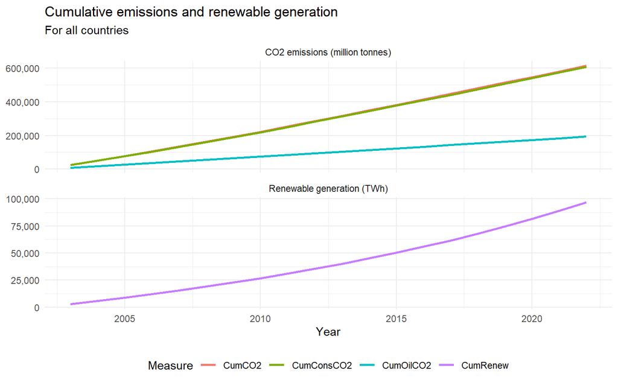

```r
cumulativeTotals <- masterData %>%
  group_by(Year) %>%
  summarise(
    CumCO2 = sum(CumCO2),
    CumOilCO2 = sum(CumOilCO2),
    CumRenew = sum(CumRenew),
    CumConsCO2 = sum(CumConsCO2)
  )

cumulativePlot <- cumulativeTotals %>%
  pivot_longer(
    cols = -Year,
    names_to = "measure",
    values_to = "value"
  ) %>%
  mutate(
    unit = if_else(
      measure == "CumRenew",
      "Renewable generation (TWh)",
      "CO2 emissions (million tonnes)"
    )
  )

ggplot(cumulativePlot, aes(Year, value, colour = measure)) +
  geom_line(linewidth = 0.9) +
  facet_wrap(~ unit, scales = "free_y", ncol = 1) +
  scale_y_continuous(labels = scales::label_comma()) +
  labs(
    title = "Cumulative emissions and renewable generation",
    subtitle = "For all countries",
    x = "Year",
    y = NULL,
    colour = "Measure",
  ) +
  theme_minimal() +
  theme(legend.position = "bottom")
```

### 2.3 Extract `lastYear_data`

*Compute the final year — do not type it in.*

```r
lastYear_data <- masterData %>%
  filter(Year == max(Year))

print(
  lastYear_data %>%
    summarise(
      finalYear = first(Year),
      countries = n()
    )
)
```

```
## # A tibble: 1 × 2
##   finalYear countries
##       <int>     <int>
## 1      2022       151
```

### 2.4 Top 10 countries on four measures

*`top10total`, `top10percap`, `top10net`, `top10renew`.*

```r
top10total <- lastYear_data %>%
  slice_max(CumCO2, n = 10)

top10percap <- lastYear_data %>%
  slice_max(CO2_PC, n = 10)

top10net <- lastYear_data %>%
  slice_max(NetImported, n = 10)

top10renew <- lastYear_data %>%
  slice_max(Renew_PC, n = 10)

print(top10total %>% select(Country, CumCO2))
```

```
## # A tibble: 10 × 2
##    Country        CumCO2
##    <chr>           <dbl>
##  1 China         177138.
##  2 United States 110533.
##  3 India          38850.
##  4 Russia         32709.
##  5 Japan          24118.
##  6 Iran           12059.
##  7 South Korea    11744.
##  8 Canada         11259.
##  9 Saudi Arabia   11169.
## 10 Indonesia       9937.
```

```r
print(top10percap %>% select(Country, CO2_PC))
```

```
## # A tibble: 10 × 2
##    Country              CO2_PC
##    <chr>                 <dbl>
##  1 Qatar                  564.
##  2 Trinidad and Tobago    554.
##  3 Curacao                527.
##  4 Bahrain                392.
##  5 Kuwait                 384.
##  6 Brunei                 376.
##  7 United Arab Emirates   354.
##  8 Saudi Arabia           347.
##  9 United States          324.
## 10 Aruba                  313.
```

```r
print(top10net %>% select(Country, NetImported))
```

```
## # A tibble: 10 × 2
##    Country        NetImported
##    <chr>                <dbl>
##  1 United States        6978.
##  2 Japan                3630.
##  3 United Kingdom       3490.
##  4 France               2576.
##  5 Italy                2422.
##  6 Singapore            2292.
##  7 Switzerland          1773.
##  8 Mexico               1517.
##  9 Hong Kong            1483.
## 10 South Korea          1457.
```

```r
print(top10renew %>% select(Country, Renew_PC))
```

```
## # A tibble: 10 × 2
##    Country     Renew_PC
##    <chr>          <dbl>
##  1 Iceland        841.
##  2 Norway         492.
##  3 Canada         208.
##  4 Bhutan         179.
##  5 Sweden         169.
##  6 Paraguay       160.
##  7 New Zealand    127.
##  8 Austria        104.
##  9 Finland        101.
## 10 Switzerland     86.2
```

### 2.5 Totals by region

```r
regionalTotals <- lastYear_data %>%
  group_by(Region) %>%
  summarise(
    CumCO2 = sum(CumCO2),
    CumOilCO2 = sum(CumOilCO2),
    CumRenew = sum(CumRenew),
    CumConsCO2 = sum(CumConsCO2)
  )

print(regionalTotals, width = Inf)
```

```
## # A tibble: 6 × 5
##   Region         CumCO2 CumOilCO2 CumRenew CumConsCO2
##   <chr>           <dbl>     <dbl>    <dbl>      <dbl>
## 1 Africa         21878.     7938.    2340.     20600.
## 2 Asia          327915.    78087.   35930.    306726.
## 3 Europe         99244.    33355.   21772.    106346.
## 4 North America 134310.    58492.   20799.    143141.
## 5 Oceania         8718.     3003.    1406.      8450.
## 6 South America  20528.    12254.   14601.     20699.
```

### 2.6 Cumulative emissions over time, top 10 countries (log Y)

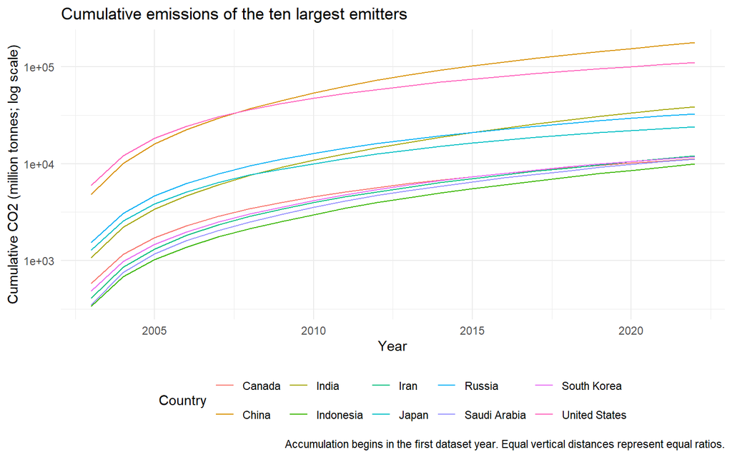

```r
topCountryHistory <- masterData %>%
  filter(ISO %in% top10total$ISO)

ggplot(topCountryHistory, aes(Year, CumCO2, colour = Country)) +
  geom_line() +
  scale_y_log10() +
  labs(
    title = "Cumulative emissions of the ten largest emitters",
    x = "Year",
    y = "Cumulative CO2 (million tonnes; log scale)",
    caption = paste(
      "Accumulation begins in the first dataset year.",
      "Equal vertical distances represent equal ratios."
    )
  ) +
  theme_minimal() +
  theme(legend.position = "bottom") +
  guides(colour = guide_legend(ncol = 5))
```

### 2.7 Faceted plot, one panel per country

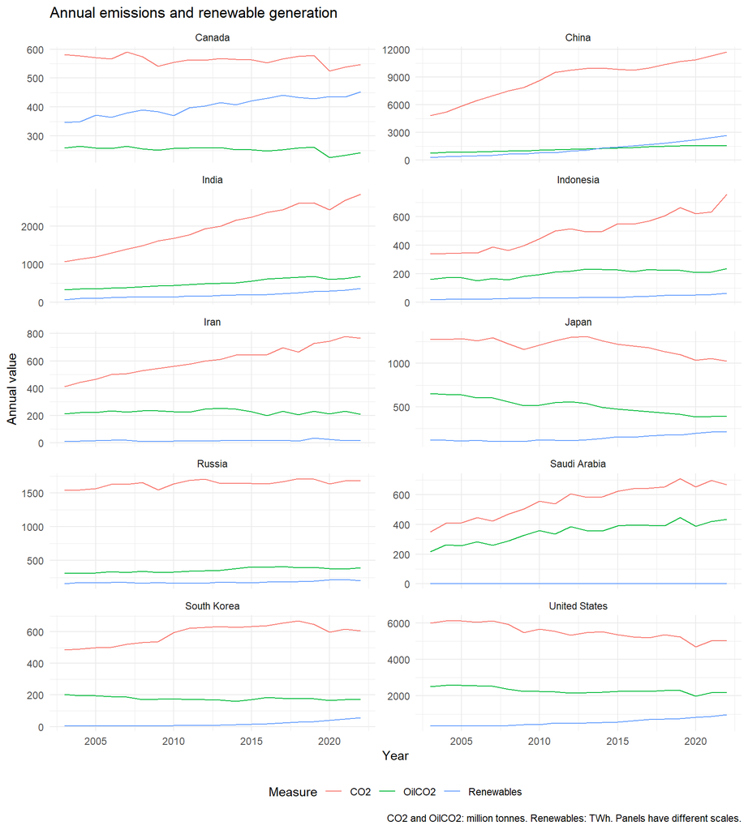

```r
annualPlot <- topCountryHistory %>%
  select(Country, Year, CO2, OilCO2, Renewables) %>%
  pivot_longer(
    cols = c(CO2, OilCO2, Renewables),
    names_to = "measure",
    values_to = "value"
  )

ggplot(annualPlot, aes(Year, value, colour = measure)) +
  geom_line() +
  facet_wrap(~ Country, scales = "free_y", ncol = 2) +
  labs(
    title = "Annual emissions and renewable generation",
    x = "Year",
    y = "Annual value",
    colour = "Measure",
    caption = paste(
      "CO2 and OilCO2: million tonnes. Renewables: TWh.",
      "Panels have different scales."
    )
  ) +
  theme_minimal() +
  theme(legend.position = "bottom")
```

### 2.8 Top 10 by emissions per capita

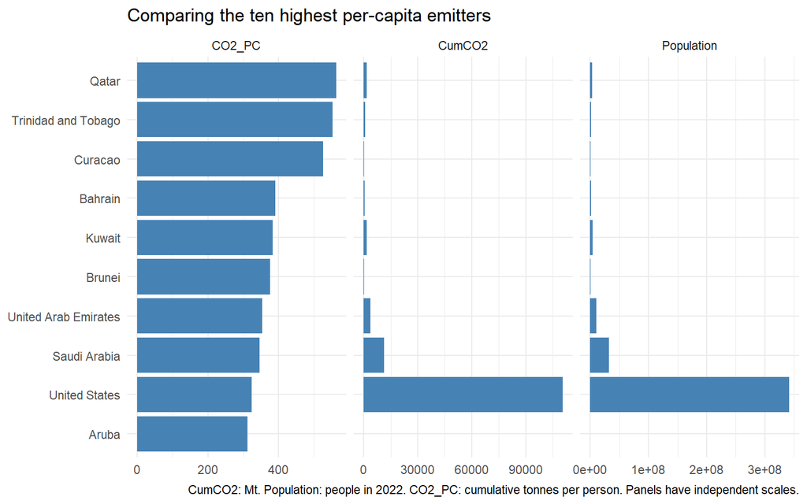

```r
perCapitaPlot <- top10percap %>%
  select(Country, CumCO2, Population, CO2_PC) %>%
  mutate(
    Country = factor(Country, levels = rev(Country))
  ) %>%
  pivot_longer(
    cols = c(CumCO2, Population, CO2_PC),
    names_to = "measure",
    values_to = "value"
  )

ggplot(perCapitaPlot, aes(value, Country)) +
  geom_col(fill = "steelblue") +
  facet_wrap(~ measure, scales = "free_x", nrow = 1) +
  labs(
    title = "Comparing the ten highest per-capita emitters",
    x = NULL,
    y = NULL,
    caption = paste(
      "CumCO2: Mt. Population: people in 2022.",
      "CO2_PC: cumulative tonnes per person. Panels have independent scales."
    )
  ) +
  theme_minimal()
```

### 2.9 Total, average and median cumulative emissions by region

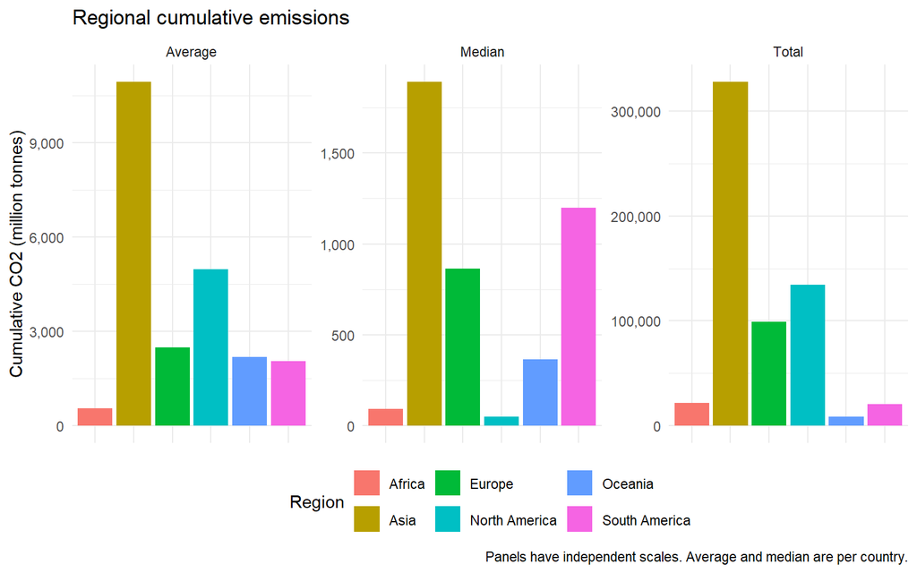

```r
regionalStatistics <- lastYear_data %>%
  group_by(Region) %>%
  summarise(
    Total = sum(CumCO2),
    Average = mean(CumCO2),
    Median = median(CumCO2)
  )

regionalPlot <- regionalStatistics %>%
  pivot_longer(
    cols = c(Total, Average, Median),
    names_to = "statistic",
    values_to = "value"
  )

ggplot(regionalPlot, aes(Region, value, fill = Region)) +
  geom_col() +
  facet_wrap(~ statistic, scales = "free_y") +
  scale_y_continuous(labels = scales::label_comma()) +
  labs(
    title = "Regional cumulative emissions",
    x = NULL,
    y = "Cumulative CO2 (million tonnes)",
    caption = "Panels have independent scales. Average and median are per country."
  ) +
  theme_minimal() +
  theme(
    axis.text.x = element_blank(),
    axis.ticks.x = element_blank(),
    legend.position = "bottom"
  )
```

### 2.10 Top 2 countries per region by emissions per capita

```r
topTwoPerRegion <- lastYear_data %>%
  group_by(Region) %>%
  slice_max(CO2_PC, n = 2) %>%
  ungroup() %>%
  select(Region, Country, CO2_PC)

print(topTwoPerRegion, n = Inf)
```

```
## # A tibble: 12 × 3
##    Region        Country             CO2_PC
##    <chr>         <chr>                <dbl>
##  1 Africa        Libya                157.
##  2 Africa        South Africa         145.
##  3 Asia          Qatar                564.
##  4 Asia          Bahrain              392.
##  5 Europe        Faroe Islands        249.
##  6 Europe        Estonia              243.
##  7 North America Trinidad and Tobago  554.
##  8 North America Curacao              527.
##  9 Oceania       Australia            304.
## 10 Oceania       New Zealand          138.
## 11 South America Venezuela            104.
## 12 South America Argentina             78.9
```

## 2A. Counterintuitive finding

*What did you expect, and why was that reasonable?*

I initially believed that total and per-capita emissions would strongly correlate with population, thus I expected China to rank highly in both total and per-capita emissions because its large cumulative emissions suggested substantial emissions relative to other countries. However, I initially underestimated how strongly population size could change the rankings.

*What does the data actually show? Quote a specific value, country or trend from your own plots.*

China has the largest cumulative emissions, at 177,138 Mt, but its cumulative emissions per person are only 124.292 tonnes. Qatar records only 1,630 Mt in cumulative emissions yet leads the per-capita ranking at 563 tonnes. Saudi Arabia and the United States are the only countries to appear in both top-ten lists.

*What real-world mechanism could explain the discrepancy?*

Population size helps explain this. China’s cumulative emissions are divided by roughly 1.425 billion people, compared with roughly 2.892 million for Qatar. It turns out countries can contribute much less in total emissions while recording substantially higher emissions per resident. Industrial structure and energy production could also contribute, although these explanations cannot directly be tested with this dataset.

### Supporting visualisation

```r
comparisonData <- lastYear_data %>%
  filter(Country %in% c("China", "Qatar")) %>%
  select(Country, CumCO2, Population, CO2_PC)

print(comparisonData)
```

```
## # A tibble: 2 × 4
##   Country  CumCO2 Population CO2_PC
##   <chr>     <dbl>      <dbl>  <dbl>
## 1 China   177138. 1425179562   124.
## 2 Qatar     1630.    2892466   564.
```

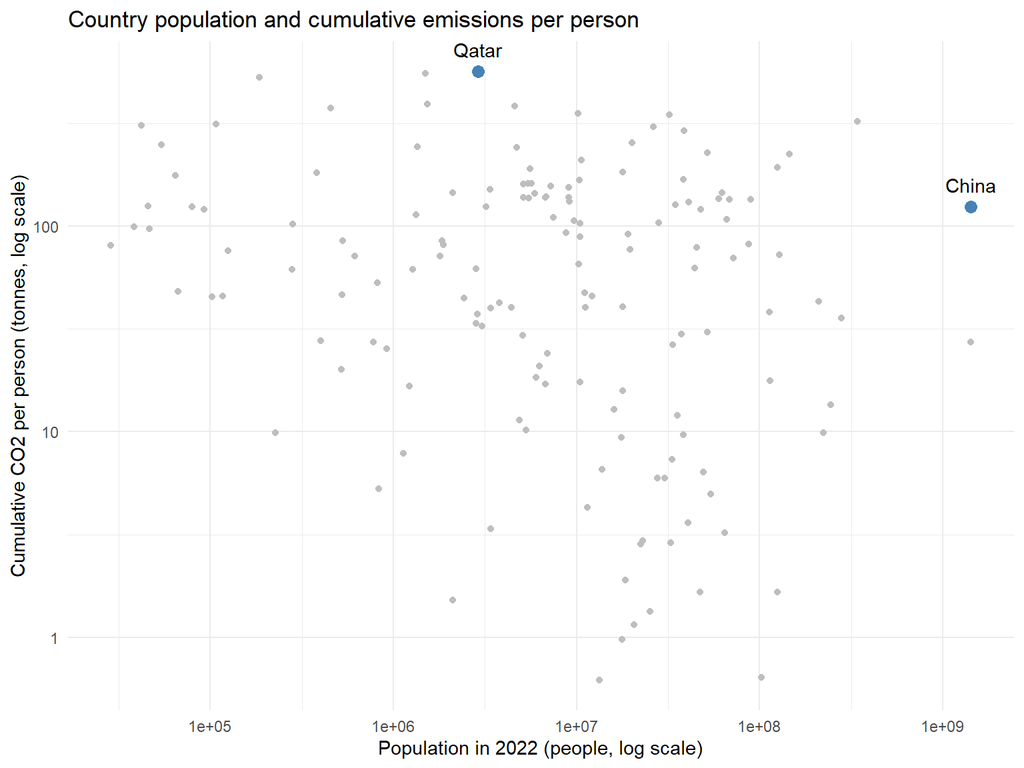

```r
ggplot(lastYear_data, aes(Population, CO2_PC)) +
  geom_point(colour = "grey") +
  geom_point(
    data = comparisonData,
    colour = "steelblue",
    size = 3
  ) +
  geom_text(
    data = comparisonData,
    aes(label = Country),
    vjust = -1
  ) +
  scale_x_log10() +
  scale_y_log10() +
  labs(
    title = "Country population and cumulative emissions per person",
    x = "Population in 2022 (people, log scale)",
    y = "Cumulative CO2 per person (tonnes, log scale)"
  ) +
  theme_minimal()
```

*Caption (2–3 sentences): what does this chart show, and why did you choose this chart type?*

This scatter plot showcases the contrasting population sizes and per-capita emissions of China and Qatar compared to other countries. The logarithmic axes make countries with widely different values comparable. I chose this chart type as it visualises the weak correlation between cumulative emissions per person and population, where I initially believed we would see a strong correlation between the two.

## 2B. Visualisation design critique

**Visualisation chosen:** *2.6 Cumulative emissions over time, top 10 countries (log Y)*

*Approximately 150 words covering: two design decisions and what each communicates; one alternative you rejected and concretely why it would communicate worse; one limitation a reader could misinterpret, and how you would mitigate it.*

The line chart communicates how cumulative emissions develop over time, while distinct colours allow readers to follow individual countries. Restricting the graph to the ten largest final-year emitters limits clutter and focuses attention on major contributors within the dataset.

The logarithmic vertical axis make the smaller differences visible. China reaches 177,138 Mt, compared with Indonesia’s 9,936 Mt. A linear-axis alternative would put more emphasis on absolute differences, but compress lower-emitting countries and make their values harder to differentiate.

One limitation is that readers may interpret equal vertical gaps as equal absolute differences. On a logarithmic scale, equal gaps represent equal ratios. Explicit axis labelling and a caption explaining this relationship reduce that risk. The caption also identifies the accumulation period, preventing readers from interpreting these values as each countries complete historical emissions.

# Task 3: Data-driven modelling

### 3.1 Build `cor_data`

```r
countryData <- lastYear_data %>%
  arrange(ISO)

cor_data <- countryData %>%
  select(CumCO2, CumConsCO2, Population, GDP, GDPCapita)

print(head(cor_data))
```

```
## # A tibble: 6 × 5
##    CumCO2 CumConsCO2 Population    GDP GDPCapita
##     <dbl>      <dbl>      <dbl>  <dbl>     <dbl>
## 1   33.7       33.7      107792   1301     12071
## 2  146.       146.     40578847  53303      1314
## 3  427.       427.     35635028 158346      4444
## 4   95.1      124.      2827614  36171     12792
## 5    9.87       9.87      79722   2306     28928
## 6 3629.      4365.     10242085 779702     76127
```

### 3.2 Correlation matrix

```r
correlationMatrix <- cor(cor_data)

print(round(correlationMatrix, 2))
```

```
##            CumCO2 CumConsCO2 Population  GDP GDPCapita
## CumCO2       1.00       0.99       0.77 0.98      0.11
## CumConsCO2   0.99       1.00       0.74 0.99      0.14
## Population   0.77       0.74       1.00 0.82     -0.05
## GDP          0.98       0.99       0.82 1.00      0.13
## GDPCapita    0.11       0.14      -0.05 0.13      1.00
```

```r
ggcorr(
  data = NULL,
  cor_matrix = correlationMatrix,
  label = TRUE,
  label_round = 2,
  low = "lightblue",
  mid = "white",
  high = "darkred",
  midpoint = 0,
  name = "Correlation"
)
```

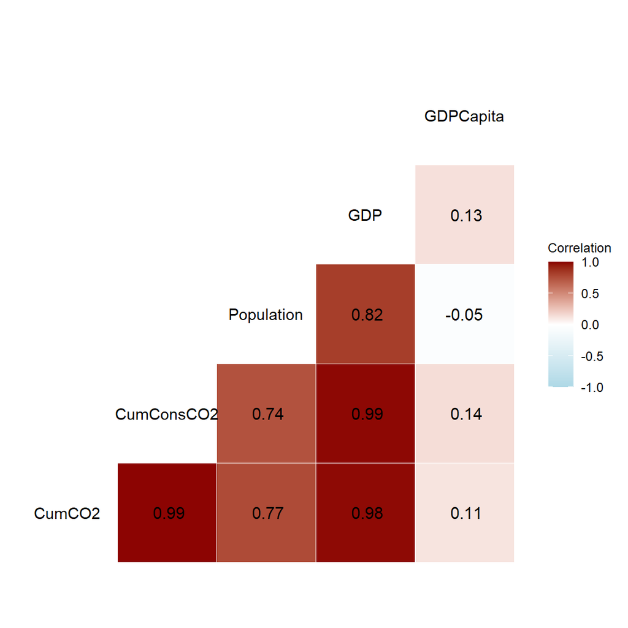

```r
gdpCorrelation <- correlationMatrix["CumCO2", "GDP"]
incomeCorrelation <- correlationMatrix["CumCO2", "GDPCapita"]

round(gdpCorrelation, 2)
```

```
## [1] 0.98
```

```r
round(incomeCorrelation, 2)
```

```
## [1] 0.11
```

*Report `cor(CumCO2, GDP)` and `cor(CumCO2, GDPCapita)`. Why are those two numbers so different?*

The correlation between CumCO2 and GDP is 0.98 and the correlation between CumCO2 and GDPCapita is 0.11. These numbers are very different because total GDP reflects the overall size of an economy, whereas GDP per capita measures economic output per person. Thus, these results suggest that cumulative emissions are more closely associated with overall economic size than with output per person.

### 3.3 Distribution of `CumCO2`, with and without log

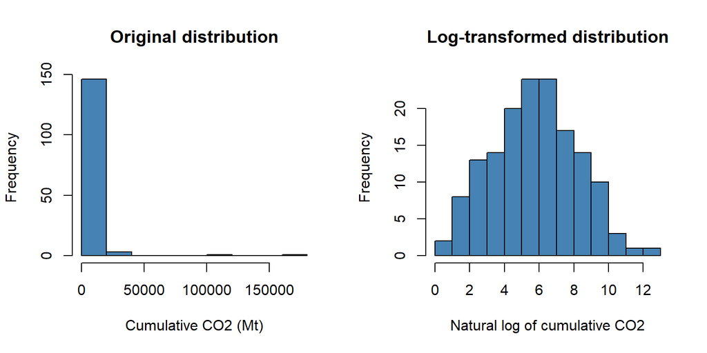

```r
par(mfrow = c(1, 2))

hist(
  cor_data$CumCO2,
  main = "Original distribution",
  xlab = "Cumulative CO2 (Mt)",
  col = "steelblue"
)

hist(
  log(cor_data$CumCO2),
  main = "Log-transformed distribution",
  xlab = "Natural log of cumulative CO2",
  col = "steelblue"
)
```

```r
par(mfrow = c(1, 1))
```

### 3.4 Train/test split

```r
## Required — do not remove or change this line:
set.seed(seed_from_id(params$studentID))

# Your 65/35 split goes below.
trainingRows <- sample(
  nrow(cor_data),
  size = floor(0.65 * nrow(cor_data))
)

trainingData <- cor_data[trainingRows, ]
testingData <- cor_data[-trainingRows, ]

trainingCountries <- countryData$Country[trainingRows]

cat("Training rows:", nrow(trainingData), "\nTesting rows:", nrow(testingData), "\n")
```

```
## Training rows: 98
## Testing rows: 53
```

### 3.5 Linear model: `CumCO2 ~ GDP`

```r
evaluateModel <- function(actualValues, predictedValues) {
  c(
    RMSE = sqrt(mean((actualValues - predictedValues)^2)),
    R2 = 1 - sum((actualValues - predictedValues)^2) /
      sum((actualValues - mean(actualValues))^2)
  )
}

gdpModel <- glm(
  CumCO2 ~ GDP,
  data = trainingData
)

gdpPredictions <- predict(
  gdpModel,
  newdata = testingData,
  type = "response"
)

gdpScores <- evaluateModel(
  testingData$CumCO2,
  gdpPredictions
)

summary(gdpModel)
```

```
##
## Call:
## glm(formula = CumCO2 ~ GDP, data = trainingData)
##
## Coefficients:
##               Estimate Std. Error t value Pr(>|t|)
## (Intercept) -6.059e+02  2.881e+02  -2.103   0.0381 *
## GDP          6.210e-03  8.253e-05  75.245   <2e-16 ***
## ---
## Signif. codes:  0 '***' 0.001 '**' 0.01 '*' 0.05 '.' 0.1 ' ' 1
##
## (Dispersion parameter for gaussian family taken to be 7616114)
##
##     Null deviance: 4.3852e+10  on 97  degrees of freedom
## Residual deviance: 7.3115e+08  on 96  degrees of freedom
## AIC: 1835
##
## Number of Fisher Scoring iterations: 2
```

```r
gdpScores
```

```
##         RMSE           R2
## 4093.4252989    0.4932483
```

### 3.6 Linear model: all predictors

```r
fullModel <- glm(
  CumCO2 ~ .,
  data = trainingData
)

fullPredictions <- predict(
  fullModel,
  newdata = testingData,
  type = "response"
)

fullScores <- evaluateModel(
  testingData$CumCO2,
  fullPredictions
)

summary(fullModel)
```

```
##
## Call:
## glm(formula = CumCO2 ~ ., data = trainingData)
##
## Coefficients:
##               Estimate Std. Error t value Pr(>|t|)
## (Intercept) -6.577e+02  1.599e+02  -4.113 8.43e-05 ***
## CumConsCO2   1.751e+00  7.798e-02  22.448  < 2e-16 ***
## Population   3.859e-05  2.055e-06  18.775  < 2e-16 ***
## GDP         -5.464e-03  5.043e-04 -10.834  < 2e-16 ***
## GDPCapita    1.601e-02  6.448e-03   2.482   0.0148 *
## ---
## Signif. codes:  0 '***' 0.001 '**' 0.01 '*' 0.05 '.' 0.1 ' ' 1
##
## (Dispersion parameter for gaussian family taken to be 1084905)
##
##     Null deviance: 4.3852e+10  on 97  degrees of freedom
## Residual deviance: 1.0090e+08  on 93  degrees of freedom
## AIC: 1646.9
##
## Number of Fisher Scoring iterations: 2
```

```r
fullScores
```

```
##         RMSE           R2
## 2742.0321016    0.7726125
```

### 3.7 Interpret and compare the two models

*When should the first be preferred, and when the second? If the full model has the higher test RMSE, explain why — that is not an error.*

The GDP-only model produced a test RMSE of 4,093.43 Mt and an R2 of 0.493, explaining approximately 49.3% of the variation in cumulative CO2 emissions in the test data. The full model performed better, with a test RMSE of 2,742.03 Mt and an R2 of 0.773, explaining approximately 77.3% of the variation. Adding the other predictors reduced test RMSE by roughly 33.0%.

Based on these results, the full model is preferable for prediction, while the GDP-only model remains useful when simplicity or limited predictor availability matters. The GDP-only coefficient represents the estimated change in cumulative emissions associated with a one-unit increase in GDP. In the full model, each coefficient describes an association while holding the other included predictors constant.

However, the full model’s performance requires caution because Task 1 replaced missing consumption emissions with production emissions. For countries with replaced values, CumConsCO2 equals CumCO2 by extension. This artificially strengthens the relationship between this predictor and the response, so the improved test results may partly reflect this replacement rather than independent prediction.

### 3.8 Alternative models

```r
# Convert train/test data into numeric matrices
trainingX <- model.matrix(CumCO2 ~ ., trainingData)[, -1]
testingX <- model.matrix(CumCO2 ~ ., testingData)[, -1]

set.seed(seed_from_id(params$studentID))

lassoModel <- cv.glmnet(
  x = trainingX,
  y = trainingData$CumCO2,
  alpha = 1,
  nfolds = 5,
  type.measure = "mse",
  standardize = TRUE
)

lassoPredictions <- as.numeric(
  predict(
    lassoModel,
    newx = testingX,
    s = "lambda.min"
  )
)

lassoScores <- evaluateModel(
  testingData$CumCO2,
  lassoPredictions
)

# Display selected lambda and predictor coefficients
print(lassoModel$lambda.min)
```

```
## [1] 138.3428
```

```r
print(coef(lassoModel, s = "lambda.min"))
```

```
## 5 x 1 sparse Matrix of class "dgCMatrix"
##                lambda.min
## (Intercept) -4.975439e+02
## CumConsCO2   9.111334e-01
## Population   2.311398e-05
## GDP          .
## GDPCapita    .
```

```r
lassoScores
```

```
##         RMSE           R2
## 3534.2298052    0.6222443
```

*Comparison table:*

| Model | RMSE | R-squared |
| --- | --- | --- |
| Linear (GDP only) | 4093.43 | 0.493 |
| Linear (all variables) | 2742.03 | 0.773 |
| Lasso regression | 3534.23 | 0.622 |

The full linear model performed best, with the lowest test RMSE (2742.03) and highest R-squared (0.773). Lasso improved on the GDP-only model but performed worse than the full model, suggesting that coefficient shrinkage and variable selection did not improve prediction on this test split.

## 3A. Assumption checking

### i. Linearity

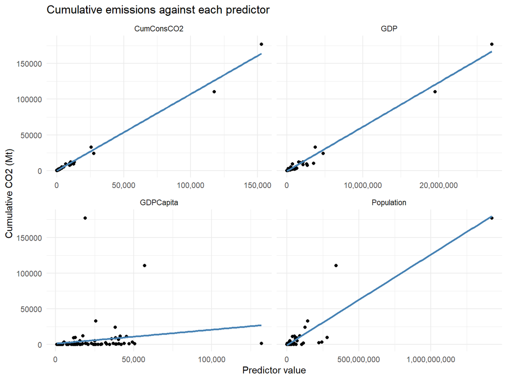

```r
linearityData <- trainingData %>%
  pivot_longer(
    cols = -CumCO2,
    names_to = "predictor",
    values_to = "value"
  )

ggplot(linearityData, aes(value, CumCO2)) +
  geom_point() +
  geom_smooth(method = "lm", se = FALSE, colour = "steelblue") +
  facet_wrap(~ predictor, scales = "free_x") +
  scale_x_continuous(labels = scales::label_comma()) +
  labs(
    title = "Cumulative emissions against each predictor",
    x = "Predictor value",
    y = "Cumulative CO2 (Mt)"
  ) +
  theme_minimal()
```

*Does a linear relationship look reasonable? Which predictor departs from it most clearly?*

A linear relationship looks reasonably plausible for CumConsCO2 and GDP, which show clear positive associations with cumulative CO2 emissions. Population also shows a positive association, although there is scattering and the trend appears strongly influenced by a few larger observations. GDPCapita departs the most from a linear relationship, the countries with similar GDP per capita have very different cumulative emissions and the points show little consistent upward trend.

### ii. Distribution of the response

*Using your plots from 3.3 — does raw `CumCO2` satisfy the normality assumption? Is a transformation warranted?*

Raw CumCO2 is strongly right-skewed, with most countries having relatively low cumulative emissions and a few showing extremely large values. The log transformation creates a much more symmetric, approximately bell-shaped distribution, suggesting it is worth investigating.

### iii. Residual diagnostics

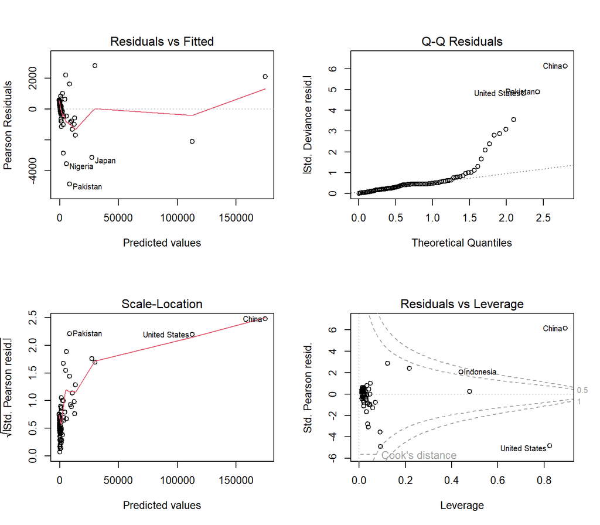

```r
par(mfrow = c(2, 2))

plot(
  fullModel,
  which = c(1, 2, 3, 5),
  labels.id = trainingCountries
)
```

```r
par(mfrow = c(1, 1))
```

| Plot | What assumption it tests | Does your model satisfy it? |
| --- | --- | --- |
| Residuals vs Fitted | Whether a linear conditional relationship is appropriate | Not really, the red line curves away from zero |
| Normal Q-Q | Whether errors are approximately normally distributed | The plot shows substantial departures from the reference line, indicating that errors are not normally distributed |
| Scale-Location | Whether error variance is approximately constant | No, the red line rises strongly with fitted values, indicating greater residual variability for countries with higher predicted emissions |
| Residuals vs Leverage | Whether individual observations exert excessive influence | China and the United States have very high leverage and large standardised residuals, indicating that they strongly influence the fitted model |

### iv. Influential observations

```r
# Remove China from the training data
trainingWithoutChina <- trainingData[-which(trainingCountries == "China"), ]

reducedModel <- glm(
  CumCO2 ~ CumConsCO2 + Population + GDP + GDPCapita,
  data = trainingWithoutChina
)

reducedPredictions <- predict(
  reducedModel,
  newdata = testingData,
  type = "response"
)

reducedScores <- evaluateModel(
  testingData$CumCO2,
  reducedPredictions
)

data.frame(
  Model = c("Full training data", "Highest-leverage country removed"),
  rbind(fullScores, reducedScores),
  row.names = NULL
)
```

```
##                              Model      RMSE        R2
## 1               Full training data 2742.0321 0.7726125
## 2 Highest-leverage country removed  932.3598 0.9737101
```

**High-leverage country:** China

**New test RMSE without it:** 932.36 Mt, originally 2742.03 Mt

*Is removing it defensible? Two sentences.*

Removing China is defensible because its high leverage and large standardised residual indicate substantial influence, and excluding it reduced the test RMSE from 2,742.03 to 932.36 Mt. However, permanent exclusion cannot be justified without evidence of a data error or a clearly defined population that excludes China, because its genuine scale is relevant for a model intended to represent all countries.

### v. Verdict

*Is linear regression a valid choice here? If assumptions are violated, what does that mean in practice for your coefficients and predictions?*

Linear regression is a useful baseline, but the full model does not adequately satisfy all assumptions. The curved residual trend suggests an imperfect linear specification, while the rising Scale-Location trend indicates unequal error variance. China and the United States also strongly influence the fit, with removing China reducing test RMSE from 2,742.03 to 932.36 Mt. This demonstrates that the coefficients may be sensitive to individual countries, conventional standard errors and confidence intervals may be unreliable, and prediction accuracy may vary considerably across country sizes. These findings support using alternative models, while using this original model as a baseline.

## 3B. Feature engineering critique

*Approximately 300 words across the three parts.*

### i. Theoretical critique

*State the physical pathway from GDP to emissions. Then explain why high correlation still does not license a causal claim: name at least two confounding or mediating variables GDP is proxying for. Reference your own correlation from 3.2, and contrast it with the `GDPCapita` correlation.*

GDP has a plausible connection to emissions, economic activity creates demand for goods, transport and energy, and fossil-fuel burning releases CO2. GDP correlates with CumCO2 at 0.98, compared with 0.11 for GDPCapita.

However, correlation does not mean causation. Total GDP partly follows population and industrial scale, while energy efficiency and industrial structure affect emissions associated with economic activity. GDP per capita removes much of the population size effect. A single GDP observation also cannot represent changing economic conditions throughout the cumulative emissions period.

### ii. Proposed feature

*Propose one engineered feature not in the dataset. Say exactly how you would construct it — what raw data, what calculation — and why it is more causally connected to emissions than GDP.*

I propose cumulative fossil-fuel burning emissions estimated from independent energy use data. For each country and year, I would get coal, oil and gas consumption in terajoules, multiply each quantity by a fuel-specific emissions factor in tonnes of CO2 per TJ, then cumsum across fuels and the dataset’s years.

This feature would follow the physical pathway from combustion to CO2 more directly than GDP. It would distinguish economies with similar output but different fossil-fuel dependence. However, it would not fully capture other emissions and must use independent energy measurements rather than derived data.

### iii. Ethical risk

*If this model allocated climate finance or set national reduction obligations, name one specific way it would be systematically unfair, and show that the unfairness comes from the structure of the model, not just “bias in the data”.*

*Use your own data: name a country with large positive `NetImported` and one with large negative `NetImported`, and build your argument around them.*

```r
# Pull out the two countries you want to use.
importCountry <- lastYear_data %>%
  slice_max(NetImported, n = 1, with_ties = FALSE)

exportCountry <- lastYear_data %>%
  slice_min(NetImported, n = 1, with_ties = FALSE)

tradeEvidence <- bind_rows(importCountry, exportCountry) %>%
  select(Country, CumCO2, CumConsCO2, NetImported)

print(tradeEvidence)
```

```
## # A tibble: 2 × 4
##   Country        CumCO2 CumConsCO2 NetImported
##   <chr>           <dbl>      <dbl>       <dbl>
## 1 United States 110533.    117512.       6978.
## 2 China         177138.    152946.     -24192.
```

A GDP-only model could give countries with similar economic output similar emissions-reduction targets, even when their energy use and trade patterns differ. This creates a risk of unfair targets because the model does not account for emissions linked to imported and exported goods.

For example, the United States has approximately 6,978 Mt of net imported emissions, while China has approximately -24,192 Mt, showing that it exports more embodied emissions than it imports. Targets based on production emissions could overlook emissions caused by American demand while holding China responsible for producing goods consumed overseas. GDP alone therefore provides an incomplete basis for sharing emissions-reduction responsibilities.

# Task 4: Insights

## Narrative thesis

*One sentence: the single story a reader should take away from your dashboard.*

Understanding the energy transition requires tracking emissions alongside renewable electricity generation, while recognising that population and trade change how national responsibility is understood.

## Dashboard sketch

*Embed your photographed hand-drawn sketch below. This is mandatory — without it you lose all design marks.*

[figure not shown]

## 4.1 Data augmentation

*How would you augment this dataset for a comprehensive view of the transition? What sources, and what would each add?*

I would add renewable electricity statistics from IRENA to examine generation by technology and renewables share of electricity generation. This would help distinguish growing renewable output from reduced dependence on fossil fuels. Sector-level energy data from the IEA would also help explain whether changes come from transport, industry, households or services.

Annual population and GDP data from the World Bank would improve comparisons over time, replacing the fixed 2022 population used in this analysis.

## 4.2 Key insights

*Which insights would you highlight for a public audience? What figures would you use, and why is each important?*

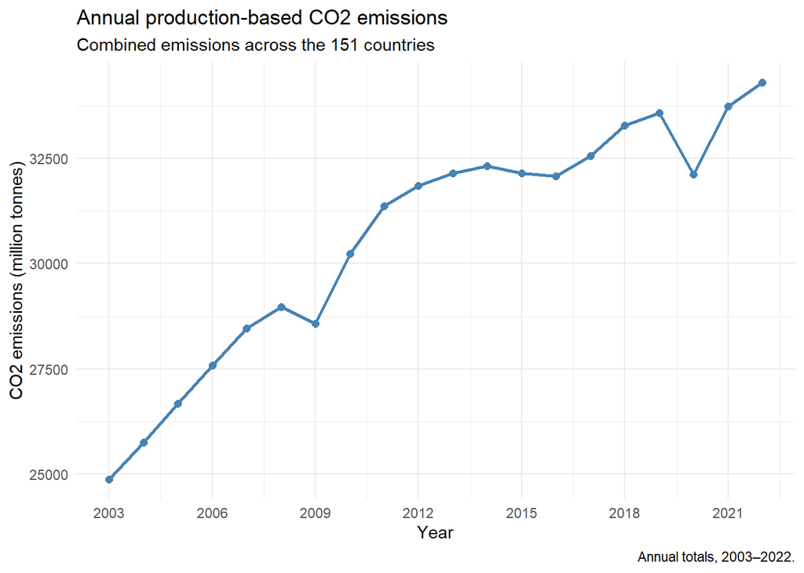

```r
# Charts used for dashboard
ggplot(annualTotals, aes(x = Year, y = totalCO2)) +
  geom_line(colour = "steelblue", linewidth = 1) +
  geom_point(colour = "steelblue", size = 2) +
  scale_x_continuous(breaks = seq(2003, 2022, by = 3)) +
  labs(
    title = "Annual production-based CO2 emissions",
    subtitle = "Combined emissions across the 151 countries",
    x = "Year",
    y = "CO2 emissions (million tonnes)",
    caption = "Annual totals, 2003–2022."
  ) +
  theme_minimal()
```

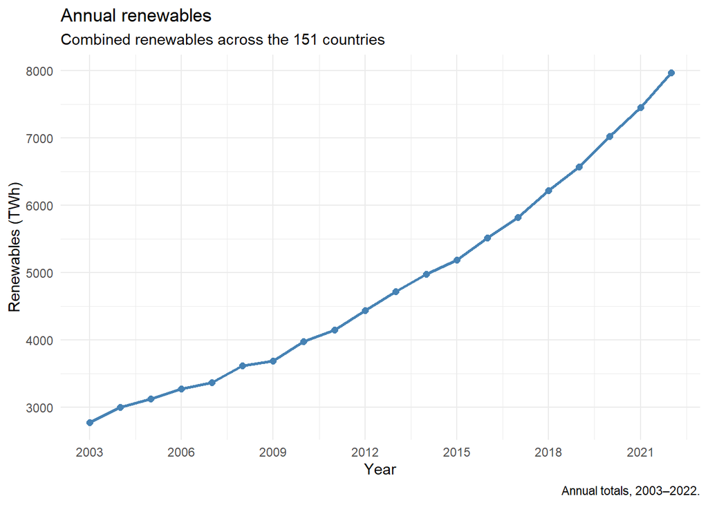

```r
renewablesAnnualTotals <- masterData %>%
  group_by(Year) %>%
  summarise(totalRenewables = sum(Renewables)) %>%
  arrange(Year)

ggplot(renewablesAnnualTotals, aes(x = Year, y = totalRenewables)) +
  geom_line(colour = "steelblue", linewidth = 1) +
  geom_point(colour = "steelblue", size = 2) +
  scale_x_continuous(breaks = seq(2003, 2022, by = 3)) +
  labs(
    title = "Annual renewables",
    subtitle = "Combined renewables across the 151 countries",
    x = "Year",
    y = "Renewables (TWh)",
    caption = "Annual totals, 2003–2022."
  ) +
  theme_minimal()
```

The dashboard introduces three headline figures: 34,306 Mt of annual CO2 emissions in 2022, the 4.35% fall in 2020, and 7,971 TWh of renewable generation in 2022. The line charts below the figures show how emissions and renewable generation changed over 2003–2022, using separate panels because their units differ.

The ranking charts show how population changes country comparisons. China leads cumulative emissions at approximately 177,138 Mt, while Qatar leads cumulative emissions per person at 563.6 tonnes. The bottom chart adds the trade perspective, comparing China’s -24,192 Mt with the United States’ +6,978 Mt of net imported emissions.

## 4.3 Design elements

*Layout, colour, typography, placement.*

The portrait layout guides readers from the title and coverage statement to headline figures, annual trends, country rankings and finally trade in order. Related charts sit beside each other, making total and per-capita rankings easy to compare.

The design uses clear headings, panel boundaries, direct labels and shading to emphasise data points. Horizontal bars accommodate country names, while the trade chart’s central zero line clearly seperates the net exporter from net importer. Titles and units are included to provide context and explain each measure.

## 4.4 Audience consideration

*How does the design serve a public audience — accessible, understandable, actionable?*

The straightforward headings such as “Are emissions falling?” help a public audience understand each chart and what its observing. Rounded figures and direct labels reduce complexity, while the reading order introduces overall trends before population and trade comparisons.

I would define Mt as million tonnes and explain net imported emissions as consumption minus production emissions. A short footer would identify the selected-country coverage and estimated values, helping readers understand the dashboard’s limitations.

## 4.5 Additional questions

*One relevant metric or visualisation you deliberately omitted, and why omitting it serves clarity.*

I omitted Task 3’s regression coefficient tables because they require substantial explanation and would distract from the dashboard’s main story. The available space instead focuses on trends and comparisons that a public audience can interpret directly.

*One way your dashboard could be misread, and how design mitigates it.*

Readers could mistake Qatar’s 563.6 tonnes per person for annual emissions. The use of footers clearing explaining what each statistic represents helps to mitigate this.

*Does your headline figure use total or per-capita emissions? Defend that choice against the obvious objection.*

The main headline uses total annual production emissions: 34,306 Mt in 2022, communicating the scale of emissions across all the countries. Although totals are influenced by population size, the prominent per-capita ranking provides a complementary comparison without treating either measure as a complete picture of country responsibility.

# Conclusions

*What are the main things your analysis shows? Keep it grounded in your own numbers.*

Across the countries, annual production emissions reached approximately 34,306 Mt in 2022, despite a 4.35% fall in 2020, while renewable electricity generation reached approximately 7,971 TWh. Country rankings changed substantially when population was considered: China led cumulative emissions at approximately 177,138 Mt, whereas Qatar led cumulative emissions per person at 563.6 tonnes. The contrasting net imported emissions of the United States (+6,978 Mt) and China (-24,192 Mt) also demonstrate why production totals alone provide an incomplete picture of responsibility.

Cumulative emissions were strongly correlated with GDP (0.98), but weakly correlated with GDP per capita (0.11). The full linear model achieved the lowest test RMSE among the three main models, at 2,742.03 Mt, compared with 4,093.43 Mt for GDP alone and 3,534.23 Mt for Lasso. However, residual problems, influential countries and the replacement of missing consumption data with production emissions limit confidence in these results. The findings therefore support considering emissions, renewable generation, population and trade together, while treating model predictions and estimated values cautiously.

# Section 5: Verification

## 5.1 Results Summary Table

*Fill every cell by hand from your own output. If you could not compute one, write `NA` and say why in a footnote below the table.*

| # | Quantity | Your value |
| --- | --- | --- |
| 1 | Dataset fingerprint (printed by the setup chunk) | EM-612876-8802-7625 |
| 2 | First and last year in your dataset | 2003, 2022 |
| 3 | Number of countries in your `Emissions.csv` | 151 |
| 4 | `dim()` of your final merged master data frame | 3020 x 23 |
| 5 | Number of duplicate rows you removed in Task 1 | 5 |
| 6 | Countries and years of the negative-emissions rows (1A ii) | Cameroon, 2012; Equatorial Guinea, 2019; Ukraine, 2016 |
| 7 | Number of countries with no consumption-based data (1A iii) | 53 |
| 8 | Year with the highest total CO2, and that total (Task 2.1) | 2022: 34,305.691 Mt |
| 9 | Top country by cumulative emissions, and by emissions per capita | China, Qatar |
| 10 | `cor(CumCO2, GDP)` and `cor(CumCO2, GDPCapita)` (2 dp) | 0.98, 0.11 |
| 11 | Test RMSE of the GDP-only model (Task 3.5) | 4,093.43 Mt |
| 12 | Test RMSE of the full model (Task 3.6) | 2,742.03 |
| 13 | The high-leverage country you identified (3A iv) | China |

```r
names(emissionsRaw)
```

```
## [1] "iso_code"          "location"          "region"
## [4] "year"              "annual_co2_mt"     "annual_oil_co2_mt"
```

## 5.2 Reproducibility appendix

*Run this chunk unchanged. Do not edit it.*

```r
cat("Student ID  :", params$studentID, "\n")
```

```
## Student ID  : u3318186
```

```r
cat("Fingerprint :", my$fingerprint, "\n")
```

```
## Fingerprint : EM-612876-8802-7625
```

```r
cat("Window      :", paste(my$window, collapse = " - "), "\n")
```

```
## Window      : 2003 - 2022
```

```r
cat("Knitted at  :", format(Sys.time(), "%Y-%m-%d %H:%M:%S %Z"), "\n")
```

```
## Knitted at  : 2026-11-17 17:40:30 AEDT
```

```r
cat("Chunks run  :", length(knitr::all_labels()), "\n\n")
```

```
## Chunks run  : 42
```

```
## [1] "R version 4.6.1 (2026-06-24 ucrt)"
```

# Appendix: Decision Log

*Minimum five entries. Write each one **at the time you make the decision**, not at the end. Every entry must reference something specific from your own analysis — a variable name, a country, a line of code, an output value. Generic entries receive zero marks. Add rows freely; more than five is viewed favourably.*

| # | Task & step | Decision made | Alternative considered | Why I chose this | Impact on results |
| --- | --- | --- | --- | --- | --- |
| 1 | 1.4 Cleaning year values | Using str_extract() | Using lubridate and parse_date_time() | Simpler for this task since it only needs the year. Using lubridate would have still required string cleaning due to the character values. | No impact, only better code. |
| 2 | 1.5 Fixing value anomaly | To scale Cameroons population by a factor of 1000 | Leaving the value as is | I chose to rescale this value as Cameroons implied population from its GDP per capita was 1000 times larger then its recorded population, implying the recorded value is in thousands scale, whereas all… | Changed Cameroons population from 27,633 to 27,633,000. |
| 3 | 1.6 Missing consumption data | Replace missing ConsC02 series with production based CO2 | Replace missing values with zero. | Zero would incorrectly assume these countries had no consumption emissions, so I used production emissions which provided a simple estimate when consumption data was unavailable. | Retained all 53 uncovered countries, but forced their estimated ‘NetImported’ value to zero. |
| 4 | 2.6 Comparing cumulative emissions | Use a log vertical axis for the ten largest emitters | Use a linear vertical axis | Chinas cumulative emissions (177,138 Mt) were much larger when compared to other countries (Indonesia, 9,937 Mt). A linear scale would make the smaller differences harder to distinguish. | Made smaller differences clearer, but verical distances represent ratios instead of absolute differences. |
| 5 | 3.8 Alternative model | Use Lasso regression with cross-validation to select penalty | Ridge regression, which shrinks coefficients but doesn’t move predictors | Lasso can shrink some coefficients to zero, allowing me to investigate if reducing unnecessary predictors improves prediction metrics | Lasso achieved a test RMSE of 3,534.23 Mt, compared with 2,742.03 Mt for the full linear model. It did not improve prediction on this test split. |

# Declaration

> I confirm that the dataset analysed in this submission was generated from my own student ID, that the values reported in Section 5.1 are the values produced by the code in this document, and that all explanations and interpretations are my own work.

> **Student ID:** u3318186 **Date:** 17/11/26